# Devoir Maison

WU Laurent

08/12/2021

# Analyse factorielle

| Code | Libellé | Nb.de.naissances.domiciliées.2020 | Produit.intérieur.brut.2018 | Taux.de.chômage.annuel.moyen.2020 | Nb.de.décès.domiciliés.2020 |
| --- | --- | --- | --- | --- | --- |
| 1 | Guadeloupe | 4678 | 9390 | 17.4 | 3742 |
| 2 | Martinique | 3529 | 8819 | 12.4 | 3586 |
| 3 | Guyane | 7992 | 4164 | 16.1 | 990 |
| 4 | La Réunion | 13142 | 19163 | 17.3 | 5154 |
| 6 | Mayotte | 9184 | 2449 | NA | 967 |
| 11 | Île-de-France | 168467 | 726164 | 7.3 | 90566 |
| 24 | Centre-Val de Loire | 25337 | 74286 | 7.4 | 28612 |
| 27 | Bourgogne-Franche-Comté | 25660 | 78367 | 6.9 | 33660 |
| 28 | Normandie | 32760 | 95064 | 7.9 | 36425 |
| 32 | Hauts-de-France | 65496 | 166519 | 9.6 | 61568 |

[output cut: 8 more lines]

*Importation du fichier CSV enregistré en UTF-8*

Hypothèse fictive :

> Le produit intérieur brut dépend du nombre de naissances domiciliées, du taux de chômage annuel et nombre de décès domiciliés

```r
str(data)
```

```
## 'data.frame':    18 obs. of  6 variables:
##  $ Code                             : int  1 2 3 4 6 11 24 27 28 32 ...
##  $ Libellé                          : chr  "Guadeloupe" "Martinique" "Guyane" "La Réunion" ...
##  $ Nb.de.naissances.domiciliées.2020: int  4678 3529 7992 13142 9184 168467 25337 25660 32760 65496 ...
##  $ Produit.intérieur.brut.2018      : int  9390 8819 4164 19163 2449 726164 74286 78367 95064 166519 ...
##  $ Taux.de.chômage.annuel.moyen.2020: num  17.4 12.4 16.1 17.3 NA 7.3 7.4 6.9 7.9 9.6 ...
##  $ Nb.de.décès.domiciliés.2020      : int  3742 3586 990 5154 967 90566 28612 33660 36425 61568 ...
```

On a ici **quatre variables** quantitatives socio-économiques :

- Nombre de naissances domiciliées
- Produit intérieur brut
- Taux de chômage annuel
- Nombre de décès domiciliés

*Représentation graphique de la dataframe*

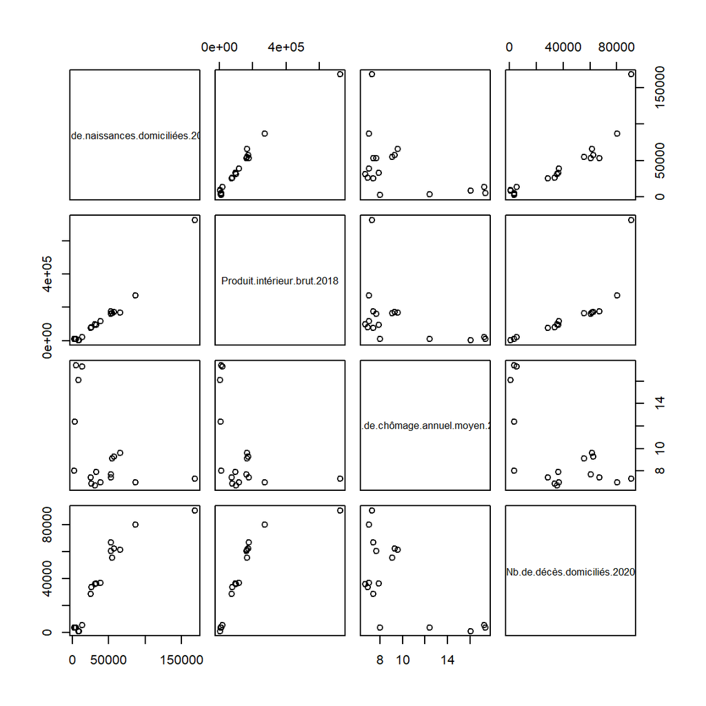

*Matrice de nuage (“scatterplot matrix”)*

> On remarque qu’il est difficile de comparer les variables car les **échelles** ne sont pas les mêmes

## **Les valeurs de dispersion et centrales**

```
##  Nb.de.naissances.domiciliées.2020 Produit.intérieur.brut.2018
##  Min.   :  2687                    Min.   :  2449
##  1st Qu.: 10174                    1st Qu.: 11873
##  Median : 31877                    Median : 96979
##  Mean   : 40770                    Mean   :131149
##  3rd Qu.: 54463                    3rd Qu.:166500
##  Max.   :168467                    Max.   :726164
##
##  Taux.de.chômage.annuel.moyen.2020 Nb.de.décès.domiciliés.2020
##  Min.   : 6.700                    Min.   :  967
##  1st Qu.: 7.300                    1st Qu.: 4095
##  Median : 7.900                    Median :36080
##  Mean   : 9.676                    Mean   :37070
##  3rd Qu.: 9.600                    3rd Qu.:61344
##  Max.   :17.400                    Max.   :90566
##  NA's   :1
```

> Les valeurs aberrantes et les *“NA”* influencent la **lisibilité** et **l’analyse**, il faut donc les supprimer.

```r
# supression des communes et des NA
suppr <- c(6,16)
data <- data[-suppr,]
data[is.na(data$Taux.de.chômage.annuel.moyen.2020 ),]
```

```
##         Nb.de.naissances.domiciliées.2020 Produit.intérieur.brut.2018
## Mayotte                              9184                        2449
##         Taux.de.chômage.annuel.moyen.2020 Nb.de.décès.domiciliés.2020
## Mayotte                                NA                         967
```

```r
data <- data [!is.na(data$Taux.de.chômage.annuel.moyen.2020),]
```

```
##                                     moy    sd coeff
## Nb.de.naissances.domiciliées.2020 31316 21805     1
## Produit.intérieur.brut.2018       90629 67851     1
## Taux.de.chômage.annuel.moyen.2020    10     4     3
## Nb.de.décès.domiciliés.2020       33024 24732     1
```

> Maintenant qu’ on a les résultats, il faut donc pouvoir comparer les valeurs des variables *indépendamment de l’unité originelle*

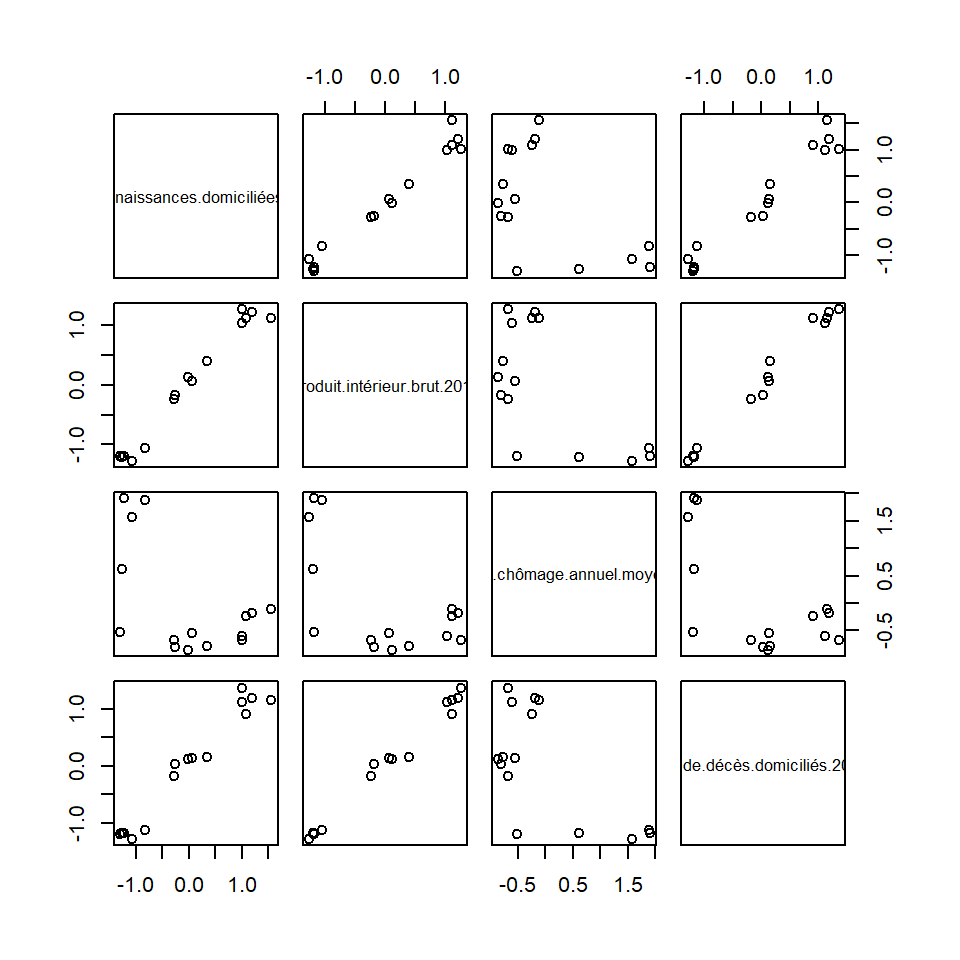

*matrice nuage de point (data_cr)*

## **Les calculs sous R (Analyse en composantes principales)**

```
##                                          PC1       PC2        PC3         PC4
## Nb.de.naissances.domiciliées.2020 -0.5225334 0.3220662 -0.7480308 -0.25235319
## Produit.intérieur.brut.2018       -0.5344481 0.1953442  0.1873214  0.80069757
## Taux.de.chômage.annuel.moyen.2020  0.3935875 0.9121895  0.1131894  0.01368598
## Nb.de.décès.domiciliés.2020       -0.5351757 0.1613203  0.6265371 -0.54315187
```

```
## [1] 0.853057425 0.141569642 0.004141269 0.001231664
```

> On a **85%** de la variance pris en compte par le premier axe, **14%** de la variance pris en compte par le deuxième axe etc.  
> Donc le premier et deuxième axe peuvent représenter **99%** de la totalité de nos données

> Sur nos données, on remarque également une forte valeur sur l’axe 2 pour le taux de chômage et une forte valeur sur l’axe 4 pour le PIB

```r
head(acp$x*-1)
```

```
##                                 PC1        PC2         PC3          PC4
## Guadeloupe               2.66396606  0.9247600  0.16403433  0.018815681
## Martinique               2.19028087 -0.2747612  0.05151620  0.011098565
## Guyane                   2.55289900  0.6339418 -0.07186342 -0.025374727
## La Réunion               2.34341914  1.0635250 -0.06650523  0.004826592
## Centre-Val de Loire      0.10138085 -0.7808220 -0.02831113 -0.036025666
## Bourgogne-Franche-Comté -0.09864604 -0.8493645  0.08511349 -0.104234675
```

> On a ci-dessus l’importation des axes pour les communes

> Exemple : la Guadeloupe obtient une valeur de **2,66** pour le premier axe, **0,92** pour le deuxième axe etc.

*Graphique de corrélation*

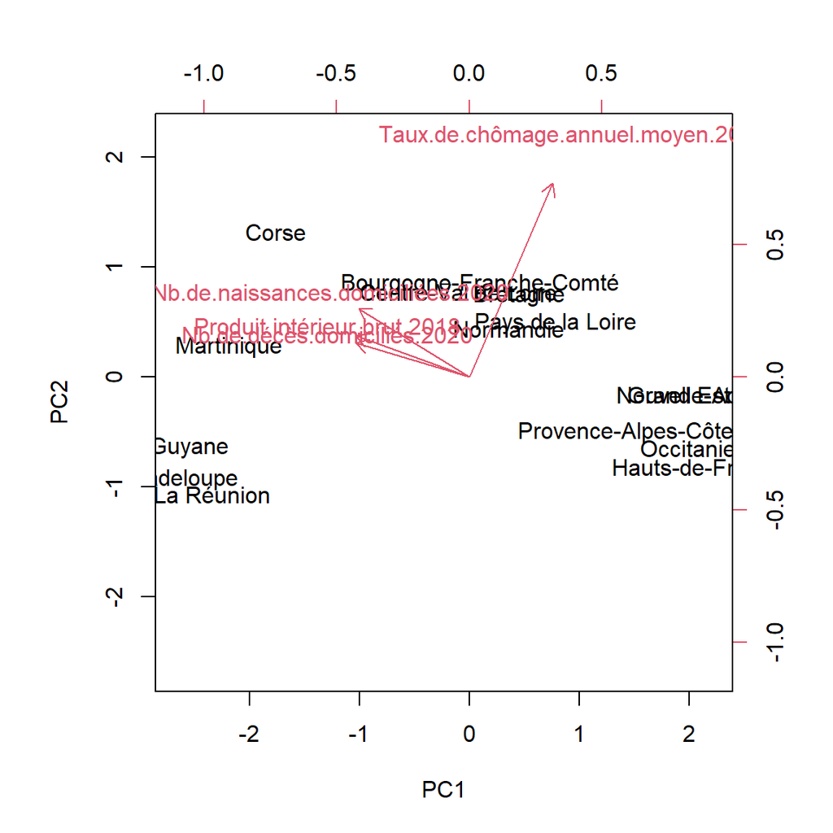

*Biplot ACP*

> Notre graphique se représente sur 2 axes.
> - La **direction** de chaque flèche illustre la variable correspondante
> - Le **sens** de chaque flèche indique la corrélation positive ou négative de la variable correspondante

> On remarque à travers le Biplot que les variables nombre de naissance, produit intérieur brut et nombre de décès sont corrélés **négativement** tandis que la variable taux de chômage est corrélé **positivement**. Il est donc intéressant de représenter les communes et visualiser ses influences dans la partie 2 (Classification)

# Classification

*Diagramme de regroupement hiérarchique*

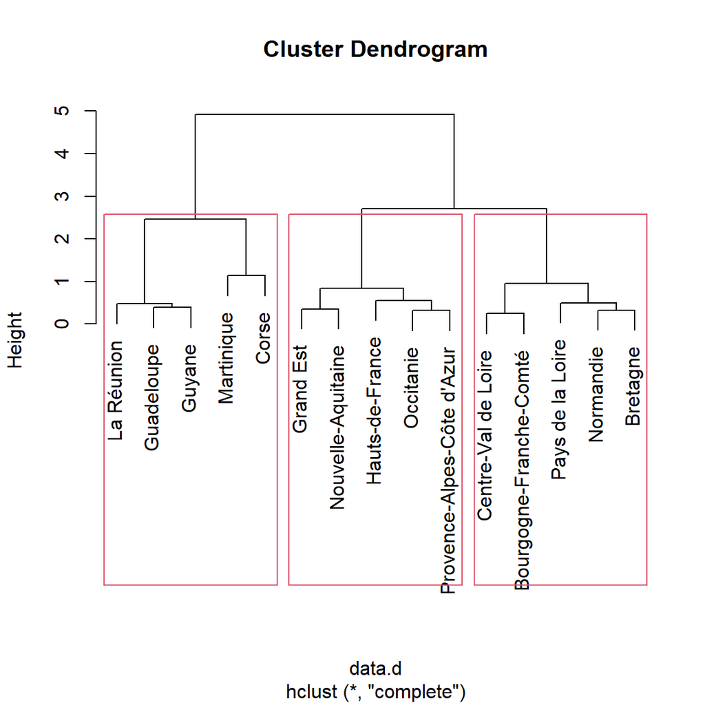

```r
#découpage
groupes.cah <- cutree(cah, k = 3)
liste <- sort(groupes.cah)
```

> Le dendrogramme suggère une solution à **3 groupes**

## **Représentation graphique**

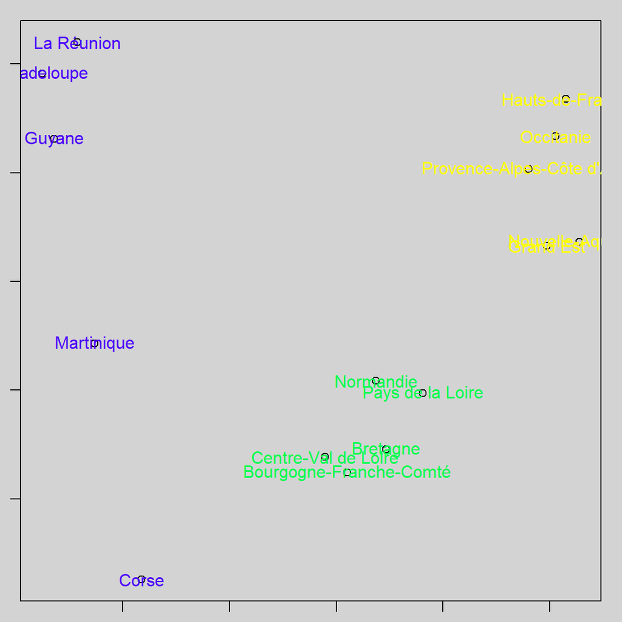

*Représentation graphique des communes*

> On peut donc remarquer une certaine tendance :
> - les communes avec un PIB élevé sont concentrés dans le groupe jaune (**forte corrélation**)
> - les communes avec un PIB moyen sont concentrés dans le groupe vert (**moyenne corrélation**)
> - les communes avec un PIB faible sont concentrés dans le groupe bleu (**faible corrélation**)

# Bonus : Magrit (Cartes)

[figure not shown]

©WU Laurent

[figure not shown]

©WU Laurent

[figure not shown]

©WU Laurent

[figure not shown]

©WU Laurent

# Script

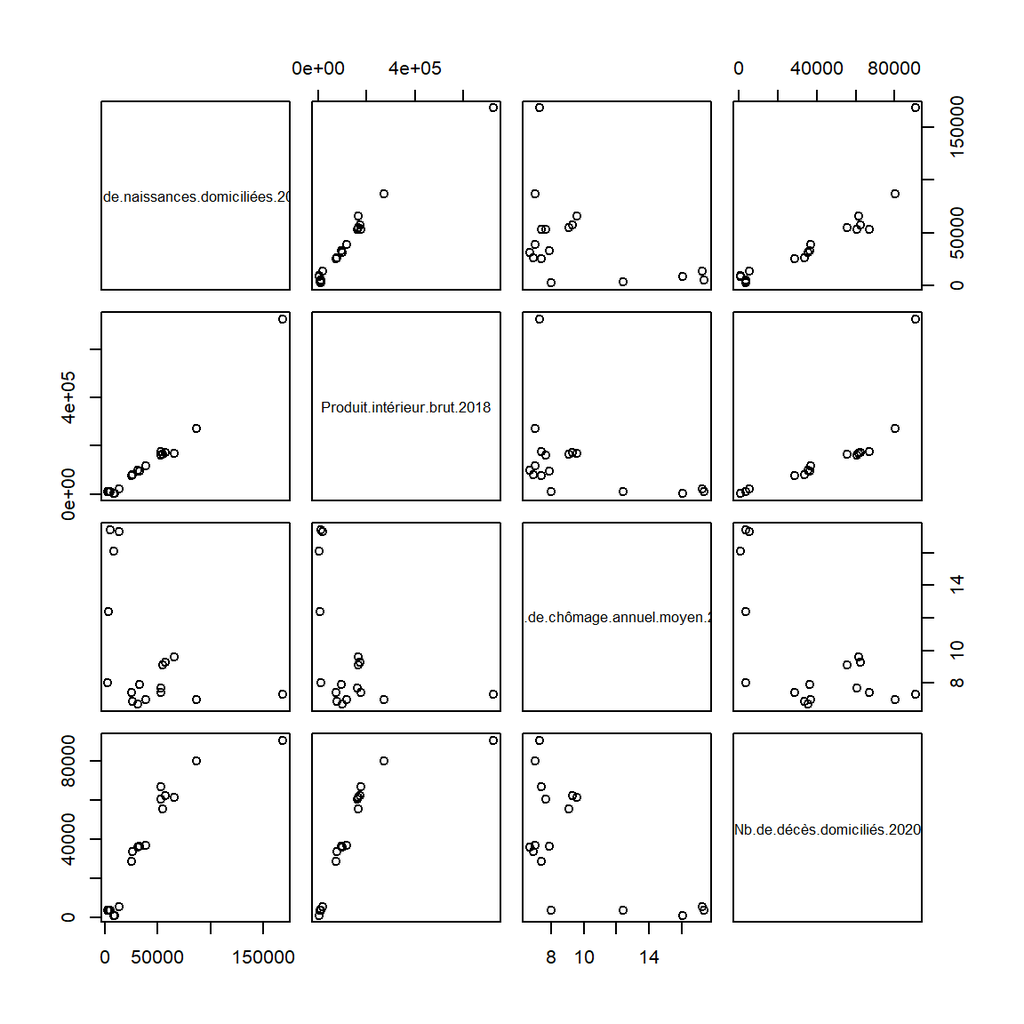

```r
# Recherche des données
data <- read.csv("data (2).csv", encoding = "UTF-8", dec = ".")
str(data)
rownames(data) <- data [,2]
data <- data [, 3:6]
pairs(data)
```

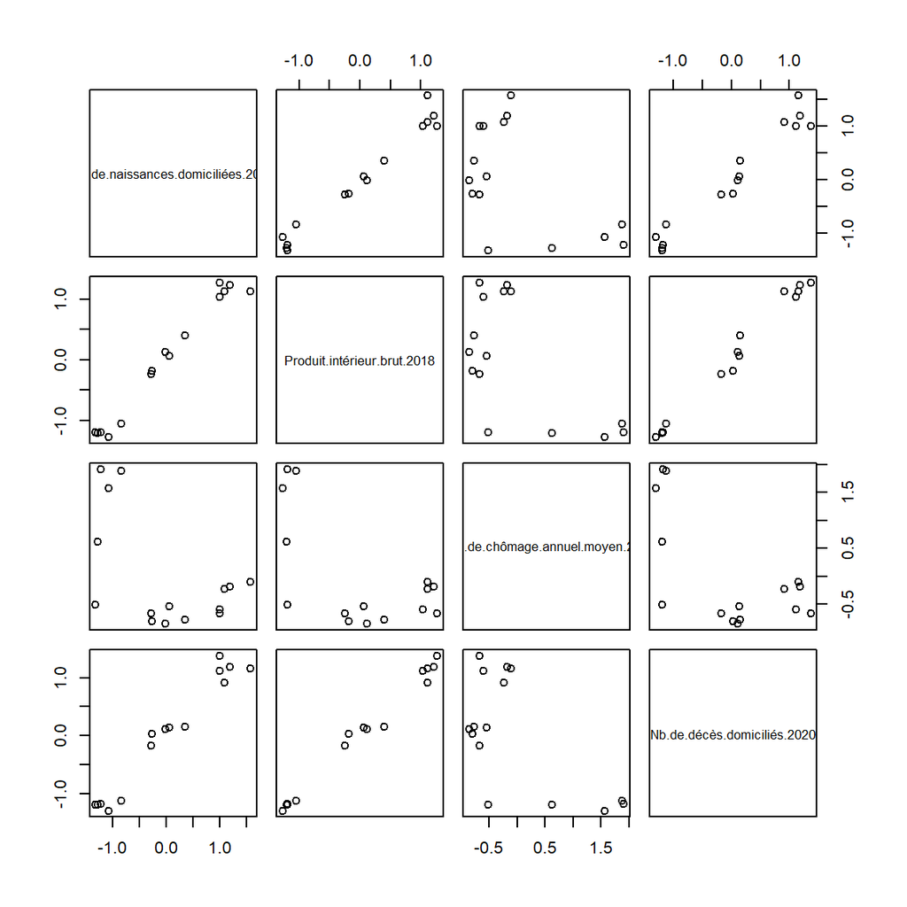

```r
# Normaliser sa donnée
summary(data)
rownames (data)

# supression des communes et des NA
suppr <- c(6,16)
data <- data[-suppr,]
data[is.na(data$Taux.de.chômage.annuel.moyen.2020 ),]
data <- data [!is.na(data$Taux.de.chômage.annuel.moyen.2020),]

# Analyse des valeurs de dispersion/centrales
coeffVariation <- function (x) {mean(x)/sd(x)}
coeff <- sapply(data, coeffVariation)
sd <- sapply(data, sd)
moy <- sapply(data, mean)
tab <- cbind(moy,sd, coeff)
round(tab,0)

# Centrage et réduction
data_cr <- scale (data)
pairs(data_cr)
```

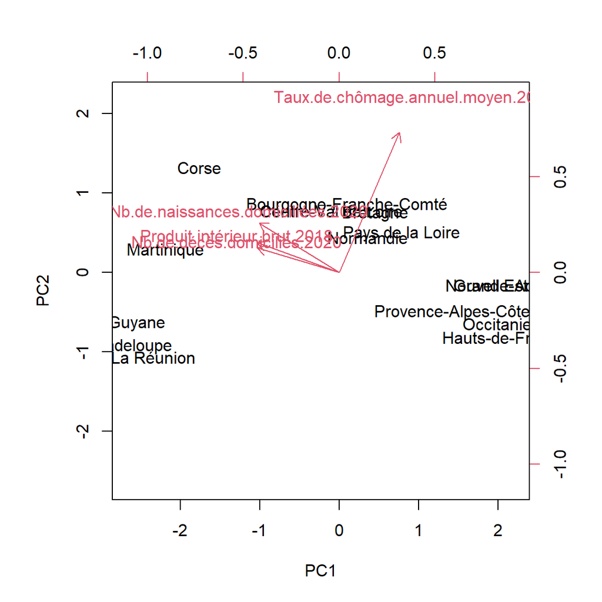

```r
# axes factoriels
acp <- prcomp(data_cr)
# par défaut direction négative ou inverse
acp$rotation <- -1 * acp$rotation
acp$rotation

# importations des axes
acp$sdev^2 / sum(acp$sdev^2)
head(acp$x*-1)
biplot(acp, scale = 0)
```

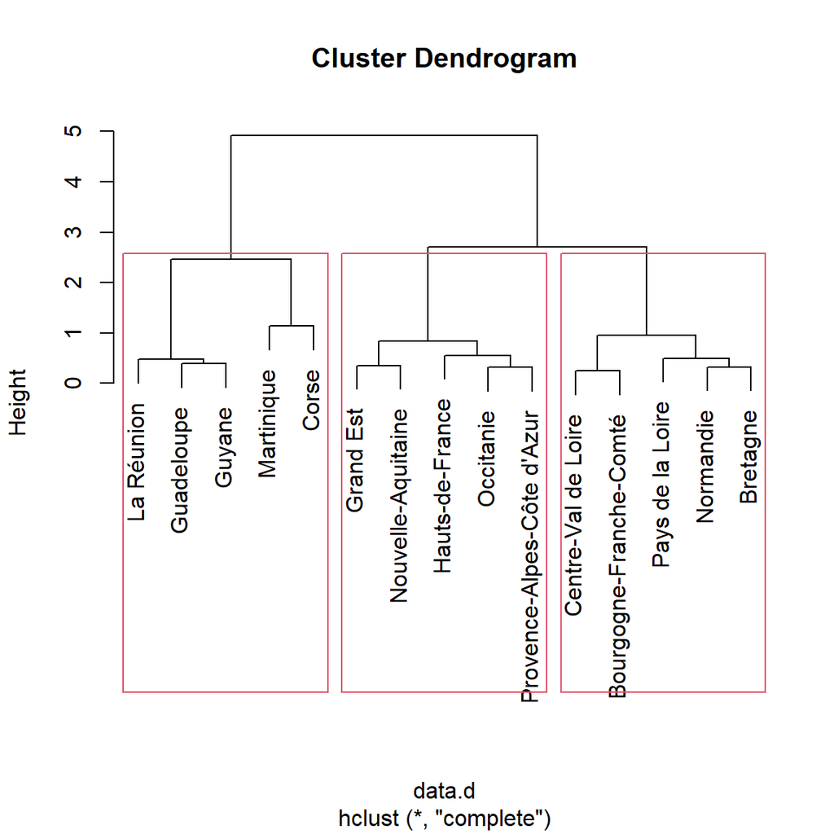

```r
# centrage et réduction
data.cr <- scale(data, center = T, scale = T)

# matrice des distances entre les individus
data.d <- dist(data.cr)

# classification
cah <- hclust(data.d)

# dendogramme
plot(cah)

# matérialisation des groupes
rect.hclust(cah, k = 3)
```

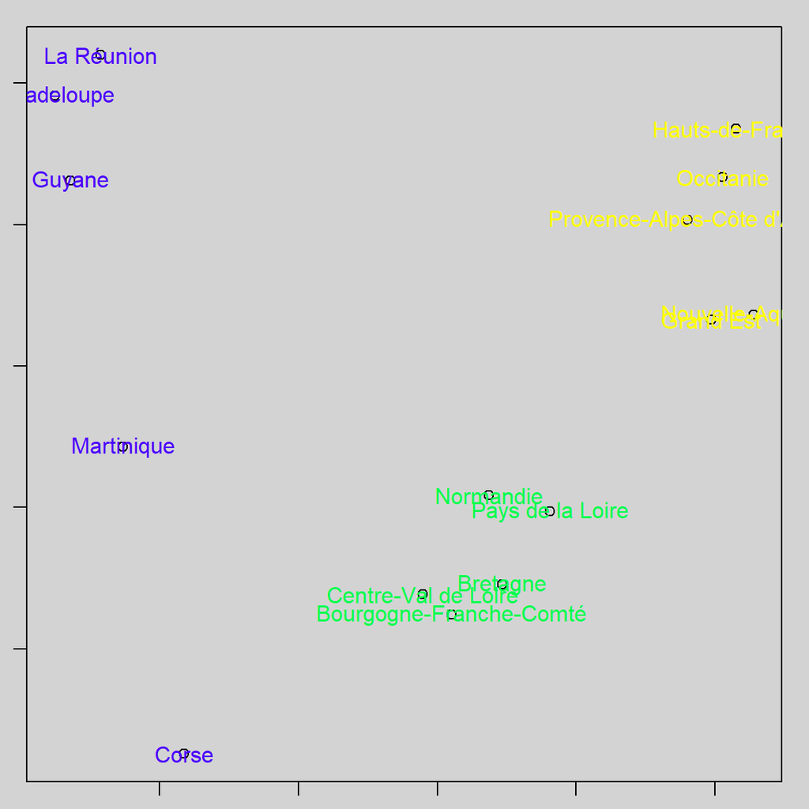

```r
groupes.cah <- cutree(cah, k = 3)
liste <- sort(groupes.cah)
acp <- princomp(data.cr, cor = T, scores = T)
par(bg = "lightgrey", mar = c(1,1,1,1))
plot(acp$scores[,1],acp$scores[,2], type = "p")
text(acp$scores[,1],acp$scores[,2],col=c(topo.colors(3))[groupes.cah],cex
     =1,labels=rownames(data))
```